# Practical Machine Learning Course Project

Edward Gañan

Sunday, May 24, 2015

This project is about human activity recognition and is concerned on how well an activity was performed by the wearer. the dataset was obteined from http://groupware.les.inf.puc-rio.br/har where 6 participants were asked to perform barbell lifts correctly and incorrectly in 5 different ways while using accelerometers on the belt, forearm, arm, and dumbell. The output was clasified in classes A, B, C, D y E, where Class A corresponds to the specified execution of the exercise, while the other 4 classes correspond to common mistakes. The goal of this project is to try to predict output class based on accelerometers measures

## Getting an cleanig data

The data are downloaded using download.file function, we have 19622 records and 160 variables

```r
pml_training<-read.csv("pml-training.csv",na.strings=c("","#DIV/0!","NA"),
                       stringsAsFactors=F)
```

takes variables only related to belt, forearm, arm, dumbell

```r
pml_training<-pml_training[,-c(1:7)]
```

remove variables with a lots NA. We ended with 52 predictors

```r
na.fn<-function(x){
  y<-prop.table(table(is.na(x)))
  r<-unname(y[names(y)==T])
  if(length(r)==0) r<-0
  r
}

var.nas<-sapply(pml_training,na.fn)
var.nas<-names(var.nas[var.nas>0.1])
pml_training<-subset(pml_training,select=names(pml_training) %in% var.nas ==F)
```

finally, we validate that we have complete cases

```r
table(complete.cases(pml_training))
```

```
##
##  TRUE
## 19622
```

## Somme exploratory anlysis

We have approximately balanced dataset

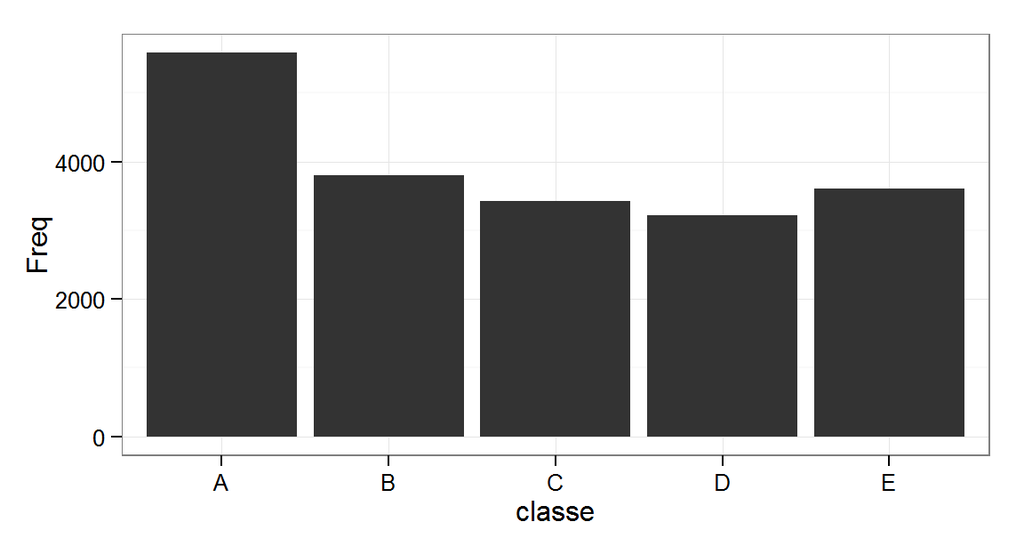

```r
dat<-as.data.frame(table(pml_training$classe))
names(dat)[1]<-"classe"
library(ggplot2)
p<-ggplot(dat,aes(x=classe,y=Freq))+geom_bar(stat="identity")+theme_bw()
p
```

We see that all variables have an important variability

```r
library(caret)
nsv<-nearZeroVar(pml_training,saveMetrics=T)
nsv
```

```
##                      freqRatio percentUnique zeroVar   nzv
## roll_belt                1.102       6.77811   FALSE FALSE
## pitch_belt               1.036       9.37723   FALSE FALSE
## yaw_belt                 1.058       9.97350   FALSE FALSE
## total_accel_belt         1.063       0.14779   FALSE FALSE
## gyros_belt_x             1.059       0.71348   FALSE FALSE
## gyros_belt_y             1.144       0.35165   FALSE FALSE
## gyros_belt_z             1.066       0.86128   FALSE FALSE
## accel_belt_x             1.055       0.83580   FALSE FALSE
## accel_belt_y             1.114       0.72877   FALSE FALSE
## accel_belt_z             1.079       1.52380   FALSE FALSE
## magnet_belt_x            1.090       1.66650   FALSE FALSE
## magnet_belt_y            1.100       1.51870   FALSE FALSE
## magnet_belt_z            1.006       2.32902   FALSE FALSE
## roll_arm                52.338      13.52563   FALSE FALSE
## pitch_arm               87.256      15.73234   FALSE FALSE
## yaw_arm                 33.029      14.65702   FALSE FALSE
## total_accel_arm          1.025       0.33636   FALSE FALSE
## gyros_arm_x              1.016       3.27693   FALSE FALSE
## gyros_arm_y              1.454       1.91622   FALSE FALSE
## gyros_arm_z              1.111       1.26389   FALSE FALSE
## accel_arm_x              1.017       3.95984   FALSE FALSE
## accel_arm_y              1.140       2.73672   FALSE FALSE
## accel_arm_z              1.128       4.03629   FALSE FALSE
## magnet_arm_x             1.000       6.82397   FALSE FALSE
## magnet_arm_y             1.057       4.44399   FALSE FALSE
## magnet_arm_z             1.036       6.44685   FALSE FALSE
## roll_dumbbell            1.022      83.78351   FALSE FALSE
## pitch_dumbbell           2.277      81.22516   FALSE FALSE
## yaw_dumbbell             1.132      83.14137   FALSE FALSE
## total_accel_dumbbell     1.073       0.21914   FALSE FALSE
## gyros_dumbbell_x         1.003       1.22821   FALSE FALSE
## gyros_dumbbell_y         1.265       1.41678   FALSE FALSE
## gyros_dumbbell_z         1.060       1.04984   FALSE FALSE
## accel_dumbbell_x         1.018       2.16594   FALSE FALSE
## accel_dumbbell_y         1.053       2.37489   FALSE FALSE
## accel_dumbbell_z         1.133       2.08949   FALSE FALSE
## magnet_dumbbell_x        1.098       5.74865   FALSE FALSE
## magnet_dumbbell_y        1.198       4.30129   FALSE FALSE
## magnet_dumbbell_z        1.021       3.44511   FALSE FALSE
## roll_forearm            11.589      11.08959   FALSE FALSE
## pitch_forearm           65.983      14.85577   FALSE FALSE
## yaw_forearm             15.323      10.14677   FALSE FALSE
## total_accel_forearm      1.129       0.35674   FALSE FALSE
## gyros_forearm_x          1.059       1.51870   FALSE FALSE
## gyros_forearm_y          1.037       3.77637   FALSE FALSE
## gyros_forearm_z          1.123       1.56457   FALSE FALSE
## accel_forearm_x          1.126       4.04648   FALSE FALSE
## accel_forearm_y          1.059       5.11161   FALSE FALSE
## accel_forearm_z          1.006       2.95587   FALSE FALSE
## magnet_forearm_x         1.012       7.76679   FALSE FALSE
## magnet_forearm_y         1.247       9.54031   FALSE FALSE
## magnet_forearm_z         1.000       8.57711   FALSE FALSE
## classe                   1.470       0.02548   FALSE FALSE
```

```r
#All are FALSE
```

Reduce dimensionality to analysis classes. 12 components are required to represent 80% of variability

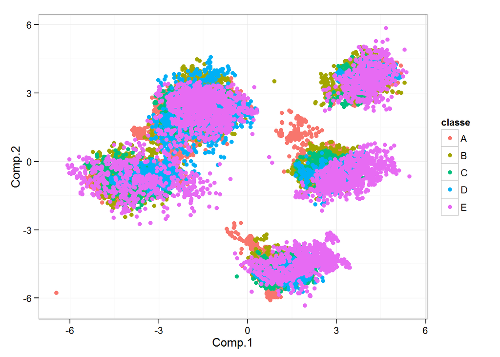

```r
pca<-princomp(pml_training[,-53],cor=T)
pca.scores<-as.data.frame(pca$scores)
pca.scores$classe<-pml_training$classe
p<-ggplot(data=pca.scores,aes(x=Comp.1,y=Comp.2,color=classe))+
    geom_point()
p<-p+theme_bw()
p
```

## Adjust prediction model

For predcition we use random forest because can consider interacction between variables and its good performance in accuracy

```r
pml_training$classe<-as.factor(pml_training$classe)
library(randomForest)
set.seed(12568)
modelRF<-randomForest(classe~.,ntree=1000,data=pml_training)
modelRF
```

```
##
## Call:
##  randomForest(formula = classe ~ ., data = pml_training, ntree = 1000)
##                Type of random forest: classification
##                      Number of trees: 1000
## No. of variables tried at each split: 7
##
##         OOB estimate of  error rate: 0.25%
## Confusion matrix:
##      A    B    C    D    E class.error
## A 5578    1    0    0    1   0.0003584
## B   10 3784    3    0    0   0.0034238
## C    0    8 3414    0    0   0.0023378
## D    0    0   20 3194    2   0.0068408
## E    0    0    1    4 3602   0.0013862
```

OOB it’s a good estimate of out of sample error and we are getting a low error prediction. Also, random forest already consider Bagging for prediction outcome.